# Taller 1 - Visualización y Exploración de bases de datos

Henry Carvajal (201718787),Julian Delgado (201712798) , Mariana Villabona (201816559)

Visualización y Exploración de datos para ciencias sociales

## Entendimiento de los datos

1. Identifique y justifique la *unidad de observación* en cada tabla de datos suministrados
- **mun_area**: Este archivo es un documento en formato csv que permite guardar información en un texto plano, donde los datos se guardan en filas y columnas separadas por comas u otro separador. Este formato permite guardar una gran cantidad de información ocupando menos espacio que un excel regular, además de ser compatible por muchos otros tipos de programa para lograr leerlos. Con respecto a los datos que contiene, cada fila describe para un municipio en Colombia en un año específico, identificado por la llave única dpmp y la columna ano_creacion. Este identificador corresponde al codigo DIVIPOLA, que es el sistema de codificacion de la division politica - administrativa de los departamentos y municipios en el territorio nacional, creado por el DANE. Además, presenta información sobre su área, el departamento al que pertenece, el año en que fue creado.
- **pob_censal**: A diferencia del archivo anterior, este es un archivo xlsx que correponde al formato regular de los archivos excel. Este permite observar los datos desde una hoja de datos, facilitando su visualizacion y manejo, aunque implicando un mayor peso de almacenamiento Cada fila describe para un municipio en Colombia en un año específico, identificado por la llave única dpmp y la columna ano. Esta llave tambien corresponde al codigo unico DIVIPOLA, por lo que desde este punto es importante asegurar que esta columna este correctaente leida y con un formato correcto para poder realizar el cruce con la tabla mun-area. Además, la tabla tambien presenta información sobre la población de dicho municipio, el departamento al que pertenece y su nombre; así cómo el año al que pertenece la información de población.

```r
summary(mun_area)
```

```
##       dp                dpmp             mpio_narea        ano_creacion
##  Length:1121        Length:1121        Min.   :   15.84   Min.   :1525
##  Class :character   Class :character   1st Qu.:  132.72   1st Qu.:1817
##  Mode  :character   Mode  :character   Median :  287.04   Median :1903
##                                        Mean   : 1017.81   Mean   :1875
##                                        3rd Qu.:  704.09   3rd Qu.:1960
##                                        Max.   :65597.21   Max.   :2019
```

```r
summary(pob_censal)
```

```
##        dp           dpnom                dpmp           mpio
##  Min.   : 5.00   Length:4488        Min.   : 5001   Length:4488
##  1st Qu.:15.00   Class :character   1st Qu.:15676   Class :character
##  Median :25.00   Mode  :character   Median :25840   Mode  :character
##  Mean   :38.28                      Mean   :38716
##  3rd Qu.:66.00                      3rd Qu.:66572
##  Max.   :99.00                      Max.   :99773
##       ano         poblacion
##  Min.   :1985   Min.   :      0
##  1st Qu.:1991   1st Qu.:   6201
##  Median :1999   Median :  11914
##  Mean   :2000   Mean   :  34058
##  3rd Qu.:2008   3rd Qu.:  23513
##  Max.   :2018   Max.   :7088156
```

2. Clasifique cada variable como identificación o medición; indique tipo y formato.

Municipios

Población

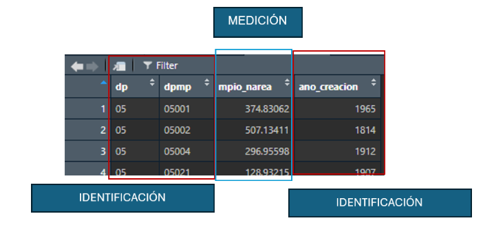

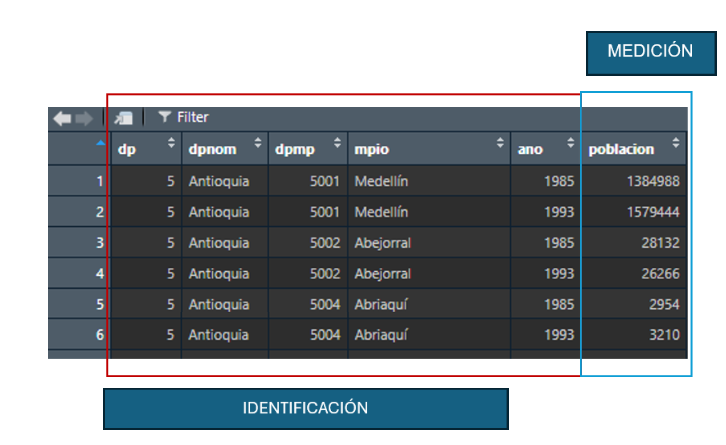

- **mun_area**: dp, dpmp son tipo carácter mientras que mpio_narea y ano_creación tipo numérico (64 bits).} Asi mismo, dp, dpmp y ano_creación son variables de identificación que guardan características especificas del municipio que representan y nos ayudan a diferenciarlas de los otros registros. Por otro lado, mpio_narea es una variable de medición que permite comparar el área del municipio con respecto al de los demás y nos permite clasificar los municipios por su tamaño o encontrar territorios con áreas similares.
- **pob_censal**: dpnom, mpio son tipo caracter mientras que dp, población, dpmp, ano son tipo numérico (64 bits). De forma similar a la tabla anterior, todas las variables con excepcion de “poblacion” son de tipo identificación que diferencian cada registro entre si, mientras que población hace referencia a una variable numérica de medición la cual nos dice cual es el número de habitantes de cada municipio en un año determinado, permitiendo analizar su  
  distribución demográfica, comparar densidades poblacionales y estudiar la evolución de la población en el tiempo.

```r
sapply(mun_area, class)
```

```
##           dp         dpmp   mpio_narea ano_creacion
##  "character"  "character"    "numeric"    "numeric"
```

```r
sapply(pob_censal, class)
```

```
##          dp       dpnom        dpmp        mpio         ano   poblacion
##   "numeric" "character"   "numeric" "character"   "numeric"   "numeric"
```

3. Proponga al menos 3 reglas mínimas de consistencia para asegurar la calidad de los datos de las variables disponibles y que constituyen parte de la documentación del ejercicio.
- **Regla 1**: La variable dp debe ser igual para cualquier municipio entre las bases de datos. (Asumiendo que los municipios no se relocalizan sobre otros departamentos).
- **Regla 2**: La población puede ser mayor o igual a cero para el año en que se reporta.
- **Regla 3**: El área de un municipio debe siempre ser mayor a cero.
- **Regla 4**: Los años con censo son: 1985,1993,2005 o 2018.

## Preparación de los datos

1. Construya la llave única para la tabla de población (sugerencia: DPMP + AÑO).

```r
# --- pob_censal ---
pob_censal <- pob_censal %>%
  mutate(
    dpmp = sprintf("%05d", as.integer(dpmp)),   # código municipal 5 dígitos
    dp   = sprintf("%02d", as.integer(dp)),     # código depto 2 dígitos
    ano = as.integer(ano),
    poblacion = as.integer(poblacion),
    llave = paste0(dpmp, "_", ano)              # llave única
  )

if ("dpnom" %in% names(pob_censal)) {
  pob_censal <- pob_censal %>%
    mutate(dpnom = tolower(iconv(dpnom, from = "UTF-8", to = "ASCII//TRANSLIT")))
}

# --- mun_area ---
mun_area <- mun_area %>%
  rename(ano = ano_creacion) %>%   # renombrar columna
  mutate(
    dpmp = sprintf("%05d", as.integer(dpmp)),
    dp   = sprintf("%02d", as.integer(dp)),
    ano  = as.integer(ano),             # ahora ya está como ano
    llave = paste0(dpmp, "_", ano)      # misma llave que pob_censal
  )
```

2. Verifique duplicados; reporte conteos y la decisión de tratamiento.
- **Respuesta**: Dado que no se presentan duplicados o valores vacíos, no se aplica tratamiento.

```r
# --- Verificar valores vacíos
cat("\n--- Número de NA's por columna en mun_area ---\n")
```

```
##
## --- Número de NA's por columna en mun_area ---
```

```r
sapply(pob_censal, function(x) sum(is.na(x)))
```

```
##        dp     dpnom      dpmp      mpio       ano poblacion     llave
##         0         0         0         0         0         0         0
```

```r
cat("\n--- Número de NA's por columna en pob_censal ---\n")
```

```
##
## --- Número de NA's por columna en pob_censal ---
```

```r
sapply(mun_area, function(x) sum(is.na(x)))
```

```
##         dp       dpmp mpio_narea        ano      llave
##          0          0          0          0          0
```

```r
# --- Verificar duplicados

# --- Población censal ---
duplicados_pob <- pob_censal %>% count(llave) %>% filter(n > 1)

cat("\n>>> Verificación de duplicados en pob_censal <<<\n")
```

```
##
## >>> Verificación de duplicados en pob_censal <<<
```

```r
if (nrow(duplicados_pob) > 0) { print(duplicados_pob)} else { cat("No se encontraron duplicados en pob_censal.\n")}
```

```
## No se encontraron duplicados en pob_censal.
```

```r
# --- Municipios / áreas ---
duplicados_area <- mun_area %>% count(llave) %>% filter(n > 1)

cat("\n>>> Verificación de duplicados en mun_area <<<\n")
```

```
##
## >>> Verificación de duplicados en mun_area <<<
```

```r
if (nrow(duplicados_area) > 0) { print(duplicados_area)
} else { cat("No se encontraron duplicados en mun_area.\n") }
```

```
## No se encontraron duplicados en mun_area.
```

```r
rm(duplicados_pob, duplicados_area)
```

3. Explique qué tipo de unión tendrían las tablas disponibles y por qué.
- **Respuesta**: Si no quisiéramos perder nada de información debería realizarse un outer join usando la llave (código municipio + año) creada anteriormente. El outer join es la manera en la que preservamos más información sobre los municipios en cada año dado que este tipo de union busca mantener todos los datos de ambas tablas a relacionar, sin darle importancia a que la llave buscada se encuentre en ambas tablas.

  En nuestro caso, dado que las bases de datos solo comparten los años 1985 y 1993; pero comparten casi todos los  
  municipios (exceptuando el 94663 solo disponible en población censal) podemos tener una base de datos única que contemple toda la información disponible en pob_censal y se complemente con información relacionada al área del municipio para los años disponibles.

  A nuestra consideración considerando que solo comparten 17 observaciones (Municipios y años comunes) podría ser de interés solo preservar la data de población censal y agregar, para los años disponibles, el área de los 17 municipios en común. Lo anterior puede realizarse con un left join o right join, dependiendo de cual tabla queramos mantener como la “principal” o la tabla maestra.

  Además, procuramos preservar el formato long dado que este formato favorece la manipulación de la información para el análisis descriptivo.

```
##
## >>> Comparación de AÑOS <<<
```

```
## Años en común: 1985 1993
```

```
## Años SOLO en pob_censal: 2005 2018
```

```
## Años SOLO en mun_area: 1525 1535 1536 1537 1538 1539 1540 1541 1542 1543 1544 1552 1555 1556 1558 1560 1563 1570 1571 1576 1580 1583 1586 1592 1593 1599 1600 1602 1604 1605 1610 1612 1613 1616 1621 1623 1627 1630 1631 1632 1638 1643 1644 1653 1660 1664 1676 1683 1690 1699 1700 1702 1707 1708 1709…
```

```
##
## >>> Comparación de MUNICIPIOS (dpmp) <<<
```

```
## Municipios en común: 1121
```

```
## Municipios SOLO en pob_censal: 1
```

```
## Municipios SOLO en mun_area: 0
```

```
##
## Ejemplos de dpmp SOLO en pob_censal:
## [1] "94663"
```

```
##
## >>> Comparación de Llaves (dpmp+año) <<<
```

```
## Llaves en común: 17
```

4. Asegure tipos de datos correctos de acuerdo con las reglas que identificó previamente ( e.g. DP, DPMP caracteres que pueden iniciar con “0”; Población entera).
- **Respuesta**: En el punto 1 de esta sección (Preparación de los datos), también nos encargamos de homogenizar la información sobre la scolumnas comunes. El filtro a continuación busca los datos negativos en población y área, en caso de no encontrar imprime “No hay población negativa”.

```
## No hay población negativa.
```

```
##          dp        dpmp  mpio_narea         ano       llave
## "character" "character"   "numeric"   "integer" "character"
```

```
##          dp       dpnom        dpmp        mpio         ano   poblacion
## "character" "character" "character" "character"   "integer"   "integer"
##       llave
## "character"
```

5. Detecte datos faltantes y decida su tratamiento, si es necesario en el contexto de este ejercicio.
- **Respuesta**: Dado que aún no hemos realizado la unión de las bases de datos; aún no es necesario el manejo de valores faltantes
6. Estandarice nombres (mayúsculas/acentos) en DPNOM y MPIO, si es necesario.
- **Respuesta**: Se estandarizan los municipios y departamentos cómo nombres propios.

```r
# Departamentos únicos
unique(pob_censal$dpnom)
```

```
##  [1] "antioquia"                  "atlantico"
##  [3] "bogota, d.c."               "bolivar"
##  [5] "boyaca"                     "caldas"
##  [7] "caqueta"                    "cauca"
##  [9] "cesar"                      "cordoba"
## [11] "cundinamarca"               "choco"
## [13] "huila"                      "la guajira"
## [15] "magdalena"                  "meta"
## [17] "narino"                     "norte de santander"
## [19] "quindio"                    "risaralda"
## [21] "santander"                  "sucre"
## [23] "tolima"                     "valle del cauca"
## [25] "arauca"                     "casanare"
## [27] "putumayo"                   "archipielago de san andres"
## [29] "amazonas"                   "guainia"
## [31] "guaviare"                   "vaupes"
## [33] "vichada"
```

```r
# Municipios únicos
unique(pob_censal$mpio)
```

```
##    [1] "Medellín"                    "Abejorral"
##    [3] "Abriaquí"                    "Alejandría"
##    [5] "Amagá"                       "Amalfi"
##    [7] "Andes"                       "Angelópolis"
##    [9] "Angostura"                   "Anorí"
##   [11] "Santafé de Antioquia"        "Anzá"
##   [13] "Apartadó"                    "Arboletes"
##   [15] "Argelia"                     "Armenia"
##   [17] "Barbosa"                     "Belmira"
##   [19] "Bello"                       "Betania"
##   [21] "Betulia"                     "Ciudad Bolívar"
##   [23] "Briceño"                     "Buriticá"
##   [25] "Cáceres"                     "Caicedo"
##   [27] "Caldas"                      "Campamento"
##   [29] "Cañasgordas"                 "Caracolí"
```

[output cut: 505 more lines]

```r
# Estandarizacion de las columna dpnom y mpio
pob_censal$dpnom <- pob_censal$dpnom %>%
  str_trim() %>%                                # quitar espacios al inicio/final
  str_to_title() %>%                            # pasar a minúsculas
  iconv(from = "UTF-8", to = "ASCII//TRANSLIT") # quitar tildes

pob_censal$mpio <- pob_censal$mpio %>%
  str_trim() %>%
  str_to_title() %>%
  iconv(from = "UTF-8", to = "ASCII//TRANSLIT")
```

7. A partir de la estructura larga de la tabla población (AÑO en columna), cree una versión ancha con columnas Pob_1985, Pob_1993, Pob_2005, Pob_2018 y guárdela en un nuevo archivo.

```r
pob_censal_ancha <- pob_censal %>%
  pivot_wider(
    id_cols = c(dp, dpnom, dpmp, mpio),
    names_from = ano,
    values_from = poblacion,
    names_prefix = "Pob_"
  )
write.xlsx(pob_censal_ancha,"stores/2.7Poblacion_censal_ancha.xsx")
```

8. Explique cuándo trabajar en largo vs. en ancho para las operaciones siguientes.
- **Respuesta**:

La decisión de trabajar los datos en formato largo (long) o ancho (wide) depende del tipo de operación que se quiera ejecutar. Al realizar una unión con otra tabla no habría mayor diferencia entre usar uno u otro formato, ya que las columnas que se expanden en el formato ancho (en este caso la población) no intervienen en el cruce de las tablas. No obstante, para fines de visualización, el formato ancho permite una comparación rápida de los valores entre diferentes años dentro de un mismo municipio o entre municipios distintos.

Por otro lado, al realizar cálculos que requieren relacionar una variable con otra (por ejemplo, población respecto al área), el formato largo suele ser más recomendable, ya que permite trabajar con todos los valores de población independientemente del año en una sola columna. En cambio, en el formato ancho sería necesario tomar cada valor de población por año y repetir la operación para cada columna.

Sin embargo, cuando se trata de comparar valores entre años específicos, como el cálculo del crecimiento poblacional entre dos censos, el formato ancho puede resultar más beneficioso, ya que basta con operar directamente entre las columnas correspondientes a cada año. En formato largo, este tipo de comparación requeriría más pasos intermedios o incluso generar una tabla auxiliar donde se almacenen los resultados.

## Integración de tablas (join), validaciones y cálculos

1. Realice la unión de las tablas población (largo) con mun_area.csv

```r
# Opción 1. Hacer un left-join usando la población poblacional. (Agrega área para 17 municipios)
pobxarea <- pob_censal %>%
  left_join(mun_area, by = c("dp", "dpmp","ano","llave"))
summary(pobxarea)
```

```
##       dp               dpnom               dpmp               mpio
##  Length:4488        Length:4488        Length:4488        Length:4488
##  Class :character   Class :character   Class :character   Class :character
##  Mode  :character   Mode  :character   Mode  :character   Mode  :character
##
##
##
##
##       ano         poblacion          llave             mpio_narea
##  Min.   :1985   Min.   :      0   Length:4488        Min.   :   41.84
##  1st Qu.:1991   1st Qu.:   6201   Class :character   1st Qu.:  403.36
##  Median :1999   Median :  11914   Mode  :character   Median :  669.90
##  Mean   :2000   Mean   :  34058                      Mean   : 4289.26
##  3rd Qu.:2008   3rd Qu.:  23513                      3rd Qu.: 1330.21
##  Max.   :2018   Max.   :7088156                      Max.   :42312.78
##                                                      NA's   :4471
```

```r
# Opción 2. Hacer un outer-join (full join) pero SOLO utilizando los departamentos y los códigos de los municipios. De forma tal que se impute la misma área para cualquier año. (Asumiendo que no cambia en el tiempo)

full_join_db <- pob_censal %>%
  full_join(mun_area, by = c("dp", "dpmp")) %>%
  select(-ends_with(".y")) %>%
  rename_with(~ sub("\\.x$", "", .x), ends_with(".x"))
summary(full_join_db)
```

```
##       dp               dpnom               dpmp               mpio
##  Length:4488        Length:4488        Length:4488        Length:4488
##  Class :character   Class :character   Class :character   Class :character
##  Mode  :character   Mode  :character   Mode  :character   Mode  :character
##
##
##
##
##       ano         poblacion          llave             mpio_narea
##  Min.   :1985   Min.   :      0   Length:4488        Min.   :   15.84
##  1st Qu.:1991   1st Qu.:   6201   Class :character   1st Qu.:  132.72
##  Median :1999   Median :  11914   Mode  :character   Median :  287.04
##  Mean   :2000   Mean   :  34058                      Mean   : 1017.81
##  3rd Qu.:2008   3rd Qu.:  23513                      3rd Qu.:  704.09
##  Max.   :2018   Max.   :7088156                      Max.   :65597.21
##                                                      NA's   :4
```

2. Reporte registros sin correspondencia en ambas direcciones.
- **Respuesta**:

Se observa que al momento de realizar la unión tipo left a partir de las llaves únicamente coinciden 17 regitros. Lo anterior porque no comparten información sobre el mismo año. Siendo así, los valores faltantes para la columna que describe el área son 4471.

Sin embargo, si realizamos una unión completa (full join), solo a partir de las columnas departamento y código de municipio (dp y dpmp), asumiendo que el área es constante a través del tiempo, se observa que únicamente 4 registros de área quedan en valor vacío: esto es, la información para todos los años asociada al municipio dpmp 9466 (Mapiripana).

```r
faltantes_en_pob_censal <- pob_censal %>%
  anti_join(mun_area, by = c("dp", "dpmp"))

faltantes_en_area <- mun_area %>%
  anti_join(pob_censal, by = c("dp", "dpmp"))
faltantes_en_pob_censal
```

```
## # A tibble: 4 × 7
##   dp    dpnom   dpmp  mpio              ano poblacion llave
##   <chr> <chr>   <chr> <chr>           <int>     <int> <chr>
## 1 94    Guainia 94663 Mapiripana (Cd)  1985         0 94663_1985
## 2 94    Guainia 94663 Mapiripana (Cd)  1993      1694 94663_1993
## 3 94    Guainia 94663 Mapiripana (Cd)  2005      1176 94663_2005
## 4 94    Guainia 94663 Mapiripana (Cd)  2018      1108 94663_2018
```

3. Documente la cardinalidad (muchos-a-uno) y cómo evita relaciones muchos-a-muchos.
- **Respuesta**: Para el left-join la relación es de uno a uno, pues al unir las bases de datos a partir de una llave única (la combinación del código del municipio y el año) solo se agrega información para filas que comparten la misma unidad de observación. Ahora bien, para la unión mediante full-join; dado que realizamos la unión de la base de datos a partir de la cardinalidad “uno a muchos” en tanto, al unir únicamente mediante departamento y código de municipio, se asignó el área de los municipios sin importar el año al que se estuviera haciendo referencia. Lo anterior se realizó bajo el supuesto de que el área asignada a cada municipio no varía en función del tiempo.

## Calculos de interes

1, Densidad poblacional = Población / MPIO_NAREA.

```r
pobxarea <- full_join_db %>%
  mutate(densidad = poblacion / mpio_narea)
pobxarea
```

```
## # A tibble: 4,488 × 9
##    dp    dpnom     dpmp  mpio         ano poblacion llave    mpio_narea densidad
##    <chr> <chr>     <chr> <chr>      <int>     <int> <chr>         <dbl>    <dbl>
##  1 05    Antioquia 05001 Medellin    1985   1384988 05001_1…      375.   3695.
##  2 05    Antioquia 05001 Medellin    1993   1579444 05001_1…      375.   4214.
##  3 05    Antioquia 05002 Abejorral   1985     28132 05002_1…      507.     55.5
##  4 05    Antioquia 05002 Abejorral   1993     26266 05002_1…      507.     51.8
##  5 05    Antioquia 05004 Abriaqui    1985      2954 05004_1…      297.      9.95
##  6 05    Antioquia 05004 Abriaqui    1993      3210 05004_1…      297.     10.8
##  7 05    Antioquia 05021 Alejandria  1985      5040 05021_1…      129.     39.1
##  8 05    Antioquia 05021 Alejandria  1993      4936 05021_1…      129.     38.3
##  9 05    Antioquia 05030 Amaga       1985     22760 05030_1…       84.1   271.
## 10 05    Antioquia 05030 Amaga       1993     24532 05030_1…       84.1   292.
## # ℹ 4,478 more rows
```

```r
write_xlsx(pobxarea,"stores/3.1 DensidadPoblacional.xlsx")
```

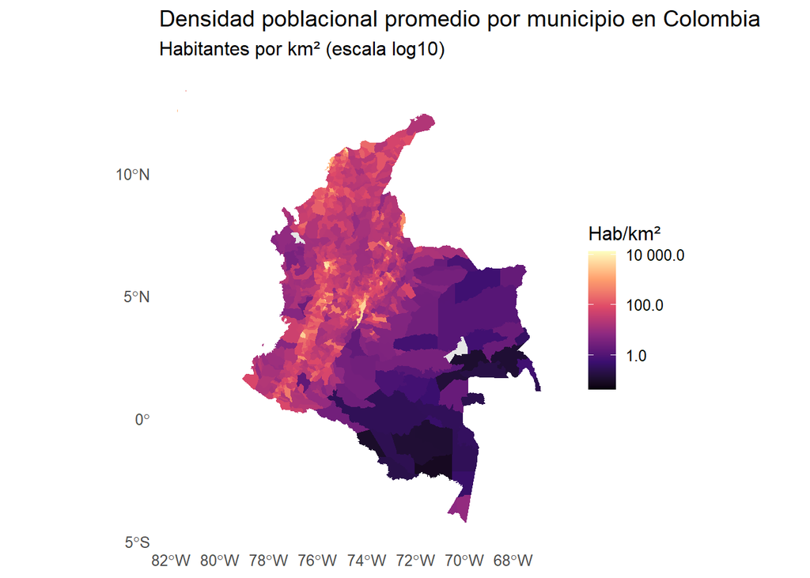

```r
# 2) Normalizar llaves (5 dígitos) en ambas tablas: pobxarea$dppmp y col_mpios$codmpio
pobxarea_key <- pobxarea %>%
  mutate(
    dpmp = as.character(dpmp),
    dpmp = str_extract(dpmp, "\\d+"),
    dpmp = str_pad(dpmp, width = 5, pad = "0")
  )

col_mpios_key <- col_mpios %>%
  mutate(
    codmpio = as.character(mpios),
    codmpio = str_extract(mpios, "\\d+"),
    codmpio = str_pad(mpios, width = 5, pad = "0")
  )

# 3) Unir por codmpio (shape) = dppmp (tu data)
map_data <- col_mpios_key %>%
  left_join(
    pobxarea_key %>% select(dpmp, densidad),
    by = c("codmpio" = "dpmp")
  )
# 4) Mapa
ggplot(map_data) +
  geom_sf(aes(fill = densidad), color = NA) +
  scale_fill_viridis_c(
    option = "magma",
    trans = "log10",
    na.value = "grey90",
    labels = scales::label_number(accuracy = 0.1)
  ) +
  labs(
    title = "Densidad poblacional promedio por municipio en Colombia",
    subtitle = "Habitantes por km² (escala log10)",
    fill = "Hab/km²"
  ) +
  theme_minimal(base_size = 12) +
  theme(panel.grid = element_blank())
```

```r
ggsave(
  filename = "stores/3.1mapa_densidad_promedio_colombia.png", # ruta y nombre del archivo
  plot = last_plot(),   # guarda el último gráfico generado
  width = 10,           # ancho en pulgadas
  height = 12,          # alto en pulgadas
  dpi = 300             # resolución (buena calidad para informes)
)
```

2. Crecimiento absoluto 1985→2018 y crecimiento porcentual 1985→2018 por municipio.

```r
pob_2 <- pobxarea %>%
  filter(ano %in% c(1985, 2018)) %>%
  select(dp, dpnom, dpmp, mpio, ano, poblacion) %>%
  pivot_wider(
    names_from = ano,
    values_from = poblacion,
    names_prefix = "Pob_"
  ) %>%
  mutate(
    crec_absoluto = Pob_2018 - Pob_1985,
    crec_porcentual = (Pob_2018 - Pob_1985) / Pob_1985 * 100
  )
print(pob_2)
```

```
## # A tibble: 1,122 × 8
##    dp    dpnom     dpmp  mpio    Pob_1985 Pob_2018 crec_absoluto crec_porcentual
##    <chr> <chr>     <chr> <chr>      <int>    <int>         <int>           <dbl>
##  1 05    Antioquia 05001 Medell…  1384988  2281316        896328           64.7
##  2 05    Antioquia 05002 Abejor…    28132    21068         -7064          -25.1
##  3 05    Antioquia 05004 Abriaq…     2954     2904           -50           -1.69
##  4 05    Antioquia 05021 Alejan…     5040     4640          -400           -7.94
##  5 05    Antioquia 05030 Amaga      22760    29724          6964           30.6
##  6 05    Antioquia 05031 Amalfi     19130    26056          6926           36.2
##  7 05    Antioquia 05034 Andes      41026    44684          3658            8.92
##  8 05    Antioquia 05036 Angelo…     6408     5768          -640           -9.99
##  9 05    Antioquia 05038 Angost…    13596    11524         -2072          -15.2
## 10 05    Antioquia 05040 Anori      12684    19026          6342           50
## # ℹ 1,112 more rows
```

```r
write_xlsx(pob_2,"stores/3.2 Crecimiento absoluto y porcentual1985-2018.xlsx")
```

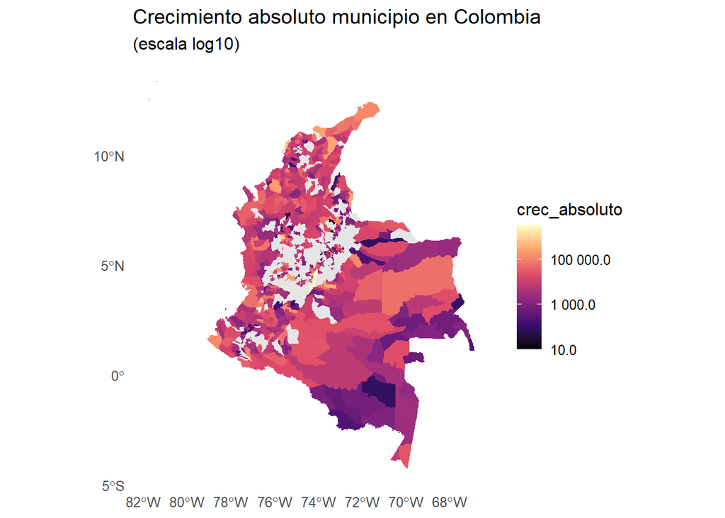

```r
# 2) Normalizar llaves (5 dígitos) en ambas tablas: pob_2$dppmp y col_mpios$codmpio
pob_2_key <- pob_2 %>%
  mutate(
    dpmp = as.character(dpmp),
    dpmp = str_extract(dpmp, "\\d+"),
    dpmp = str_pad(dpmp, width = 5, pad = "0")
  )

col_mpios_key <- col_mpios %>%
  mutate(
    codmpio = as.character(mpios),
    codmpio = str_extract(mpios, "\\d+"),
    codmpio = str_pad(mpios, width = 5, pad = "0")
  )

# 3) Unir por codmpio (shape) = dppmp (tu data)
map_data <- col_mpios_key %>%
  left_join(
    pob_2_key %>% select(dpmp, crec_absoluto, crec_porcentual),
    by = c("codmpio" = "dpmp")
  ) %>%
  mutate(
    # Evitar infinitos/NaN cuando Pob_1985 = 0
    crec_porcentual = ifelse(is.infinite(crec_porcentual) | is.nan(crec_porcentual), NA, crec_porcentual)
  )

# 4) Mapa crecimiento absoluto
ggplot(map_data) +
  geom_sf(aes(fill = crec_absoluto), color = NA) +
  scale_fill_viridis_c(
    option = "magma",
    trans = "log10",
    na.value = "grey90",
    labels = scales::label_number(accuracy = 0.1)
  ) +
  labs(
    title = "Crecimiento absoluto municipio en Colombia",
    subtitle = "(escala log10)",
  ) +
  theme_minimal(base_size = 12) +
  theme(panel.grid = element_blank())
```

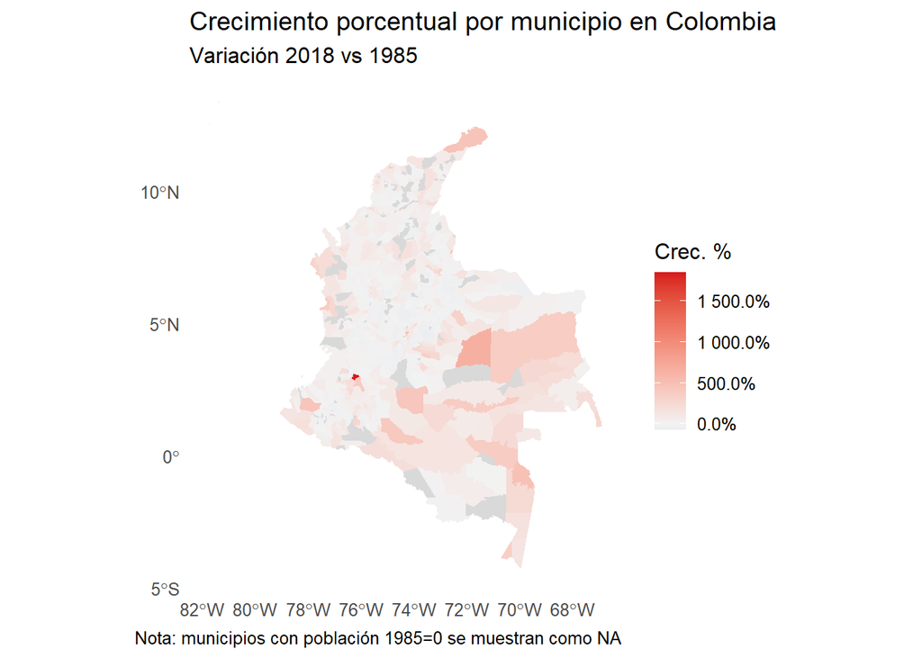

```r
# --- Guardar en PNG -------------------------------------------------
ggsave(
  filename = "stores/mapas_crecimiento_absoluto_1985_2018.png",
  plot = last_plot(), width = 14, height = 10, dpi = 300
)

# 5) Mapa crecimiento porcentual
lab_pct <- scales::percent_format(accuracy = 0.1, scale = 1)

ggplot(map_data) +
  geom_sf(aes(fill = crec_porcentual), color = NA) +
  scale_fill_gradient2(
    low = "#2C7BB6", mid = "grey95", high = "#D7191C",
    midpoint = 0,
    na.value = "grey85",
    labels = lab_pct,
    name = "Crec. %"
  ) +
  labs(
    title = "Crecimiento porcentual por municipio en Colombia",
    subtitle = "Variación 2018 vs 1985",
    caption = "Nota: municipios con población 1985=0 se muestran como NA"
  ) +
  theme_minimal(base_size = 12) +
  theme(panel.grid = element_blank())
```

```r
# --- Guardar en PNG -------------------------------------------------
ggsave(
  "stores/mapa_crecimiento_porcentual_1985_2018.png",
  plot = last_plot(), width = 10, height = 12, dpi = 300
)
```

3. Agregación por departamento (DP) para densidad y crecimiento (aclare la definición usada).

```r
agg_departamento <- pobxarea %>%
  filter(ano %in% c(1985, 2018)) %>%
  group_by(dp, dpnom, ano) %>%
  summarise(
    pob_total = sum(poblacion, na.rm = TRUE),
    area_total = sum(mpio_narea, na.rm = TRUE),
    .groups = "drop"
  ) %>%
  mutate(densidad = pob_total / area_total) %>%
  pivot_wider(
    names_from = ano,
    values_from = c(pob_total, densidad),
    names_sep = "_"
  ) %>%
  mutate(
    crec_abs = pob_total_2018 - pob_total_1985,
    crec_pct = (pob_total_2018 - pob_total_1985) / pob_total_1985 * 100
  )
```

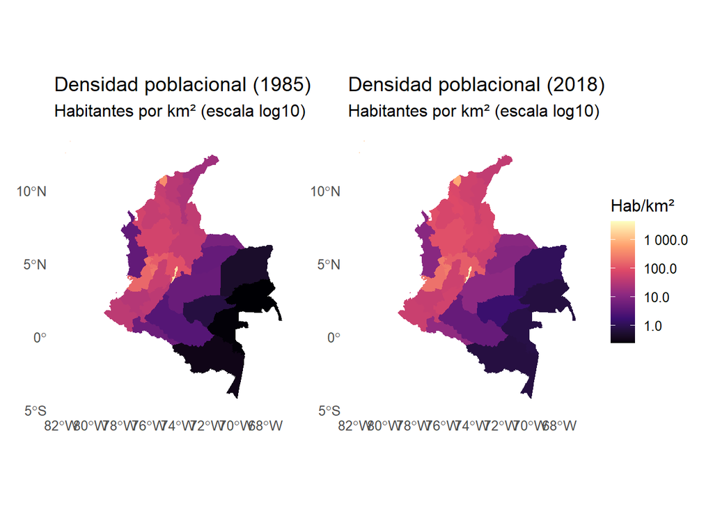

```r
agg_departamento_key <- agg_departamento %>%
  mutate(
    dp = as.character(dp),
    dp = str_extract(dp, "\\d+"),
    dp = str_pad(dp, width = 5, pad = "0")
  )

col_mpios_key <- col_mpios %>%
  mutate(
    dpto = as.character(dpto),
    dpto = str_extract(dpto, "\\d+"),
    dpto = str_pad(dpto, width = 5, pad = "0")
  )

# 3) Unir por codmpio (shape) = dppmp (tu data)
map_data <- col_mpios_key %>%
  left_join(
    agg_departamento_key %>%
      select(dp, densidad_1985, densidad_2018, crec_abs, crec_pct),
    by = c("dpto" = "dp")
  ) %>%
  mutate(
    # reemplaza Inf/NaN por NA
    crec_pct = replace(crec_pct, !is.finite(crec_pct), NA_real_)
  )

# Crear map_dens y límites comunes robustos
map_dens <- map_data %>%
  mutate(
    d85 = ifelse(is.finite(densidad_1985) & densidad_1985 > 0, densidad_1985, NA_real_),
    d18 = ifelse(is.finite(densidad_2018) & densidad_2018 > 0, densidad_2018, NA_real_)
  )

lims <- range(c(map_dens$d85, map_dens$d18), na.rm = TRUE)

# Si hubo todo NA/Inf o iguales, ajustamos
if (!all(is.finite(lims))) {
  # mete un 1 para evitar rango no finito (solo si todo estaba NA)
  lims <- range(c(1, map_dens$d85, map_dens$d18), na.rm = TRUE)
}
if (diff(lims) == 0) {        # evita límites idénticos
  lims <- lims + c(-0.5, 0.5)
}

# Etiquetador compatible según versión de 'scales'
lab_num <- if (utils::packageVersion("scales") >= "1.2.0") {
  scales::label_number(accuracy = 0.1)
} else {
  scales::comma_format(accuracy = 1)
}

# Mapas
p85 <- ggplot(map_dens) +
  geom_sf(aes(fill = d85), color = NA) +
  scale_fill_viridis_c(
    option = "magma",
    trans = "log10",
    limits = lims,                 # <= ojo: con "="
    oob = scales::squish,          # valores fuera de rango, los “aprieta”
    na.value = "grey90",
    labels = lab_num,
    name = "Hab/km²"
  ) +
  labs(title = "Densidad poblacional (1985)",
       subtitle = "Habitantes por km² (escala log10)") +
  theme_minimal(base_size = 12) +
  theme(panel.grid = element_blank())

p18 <- ggplot(map_dens) +
  geom_sf(aes(fill = d18), color = NA) +
  scale_fill_viridis_c(
    option = "magma",
    trans = "log10",
    limits = lims,                 # <= mismo rango para comparar
    oob = scales::squish,
    na.value = "grey90",
    labels = lab_num,
    name = "Hab/km²"
  ) +
  labs(title = "Densidad poblacional (2018)",
       subtitle = "Habitantes por km² (escala log10)") +
  theme_minimal(base_size = 12) +
  theme(panel.grid = element_blank())

# Combinar y guardar
if (!requireNamespace("patchwork", quietly = TRUE)) install.packages("patchwork")
library(patchwork)

p_combo <- p85 + p18 + plot_layout(ncol = 2, guides = "collect") &
  theme(legend.position = "right")

p_combo
```

```r
ggsave("stores/mapas_densidad_1985_2018.png", p_combo, width = 14, height = 10, dpi = 300)
```

## Preguntas de indagación

```r
crecimiento_poblacional <- full_join_db %>%
  group_by(mpio) %>%
  summarise(
    pob_1985 = sum(poblacion[ano == 1985], na.rm = TRUE),
    pob_2018 = sum(poblacion[ano == 2018], na.rm = TRUE)
  ) %>%
  mutate(
    crecimiento_abs = pob_2018 - pob_1985,
    crecimiento_pct = (pob_2018 / pob_1985 - 1) * 100
  ) %>%
  arrange(desc(crecimiento_pct))

tabla_abs <- crecimiento_poblacional %>% # Tabla primeros 20 crecimiento absoluto
  select(mpio, crecimiento_abs) %>%
  head(20)

tabla_pct <- crecimiento_poblacional %>%  # Tabla primeros 20 crecimiento porcentual
  filter(is.finite(crecimiento_pct)) %>%   # quita Inf, -Inf y NaN
  select(mpio, crecimiento_pct) %>%
  slice_max(order_by = crecimiento_pct, n = 20, with_ties = FALSE)

tabla_abs
```

```
## # A tibble: 20 × 2
##    mpio                    crecimiento_abs
##    <chr>                             <int>
##  1 Algarrobo                         16074
##  2 Altos Del Rosario                 11442
##  3 Arenal                             7624
##  4 Arroyohondo                        8340
##  5 Atrato                             6118
##  6 Barranca De Upia                   6522
##  7 Cantagallo                         8702
##  8 Carmen Del Darien                 19276
##  9 Certegui                           5248
## 10 Chachagui                         15282
## 11 Chivor                             2680
## 12 Cicuco                            13580
## 13 Clemencia                         14696
## 14 Cotorra                           19092
## 15 Covenas                           20534
## 16 Dibulla                           38512
## 17 Distraccion                       13210
## 18 El Canton Del San Pablo            5996
## 19 El Carmen De Chucuri              21698
## 20 El Dorado                          3978
```

```r
tabla_pct
```

```
## # A tibble: 20 × 2
##    mpio                 crecimiento_pct
##    <chr>                          <dbl>
##  1 Toribio                        1850.
##  2 Puerto Gaitan                   651.
##  3 Suarez                          648.
##  4 Los Patios                      502.
##  5 Taraira                         486.
##  6 Manaure                         470.
##  7 Uribia                          456.
##  8 Mosquera                        451.
##  9 Magui                           440.
## 10 La Macarena                     435.
## 11 Cartagena Del Chaira            407.
## 12 San Miguel                      394.
## 13 Pacoa (Cd)                      379.
## 14 El Retorno                      376.
## 15 Cumaribo                        365.
## 16 Nuqui                           365.
## 17 Galapa                          359.
## 18 Puerto Narino                   350.
## 19 Castilla La Nueva               344.
## 20 Yopal                           313.
```

```r
# Guardar en Excel
if(!dir.exists("stores")) {
  dir.create("stores")
}
write_xlsx(crecimiento_poblacional, "stores/crecimiento_poblacional.xlsx")
rm(tabla_abs, tabla_pct,crecimiento_poblacional)
```

```r
densidad_municipios <- full_join_db %>%
  group_by(mpio) %>%
  summarise(
    den_1993 = sum(poblacion[ano == 1993], na.rm = TRUE)/ sum(mpio_narea[ano == 1993], na.rm = TRUE),
    den_2018 = sum(poblacion[ano == 2018], na.rm = TRUE)/ sum(mpio_narea[ano == 2018], na.rm = TRUE)
  )

den_1993 <- densidad_municipios %>%
  arrange(desc(den_1993)) %>%
  select(mpio, den_1993) %>%
  head(10)

den_2018 <- densidad_municipios %>%
  arrange(desc(den_2018)) %>%
  select(mpio, den_2018) %>%
  head(10)

den_1993
```

```
## # A tibble: 10 × 2
##    mpio            den_1993
##    <chr>              <dbl>
##  1 Mapiripana (Cd)     Inf
##  2 Itagui             8331.
##  3 Barranquilla       5900.
##  4 Soledad            4396.
##  5 Medellin           4214.
##  6 Cali               3203.
##  7 Bogota, D.c.       3121.
##  8 Bucaramanga        2326.
##  9 Sabaneta           2212.
## 10 Dosquebradas       2029.
```

```r
den_2018
```

```
## # A tibble: 10 × 2
##    mpio            den_2018
##    <chr>              <dbl>
##  1 Mapiripana (Cd)     Inf
##  2 Itagui            13416.
##  3 Soledad            9916.
##  4 Barranquilla       7494.
##  5 Medellin           6086.
##  6 Sabaneta           4838.
##  7 Bogota, D.c.       4368.
##  8 Cali               3704.
##  9 Bucaramanga        3607.
## 10 Soacha             3418.
```

- **Respuesta**: Entre 1993 y 2018 los municipios de Itagüí, Soledad, Barranquilla, Medellín, Bogotá, Cali y Bucaramanga se presentan como los territorios con mayor densidad poblacional en Colombia. Esto es espcialmente relevante para el caso de Itagui y Atlantico dado a que presentan las mayores densidades, a pesar de no ser los principales municipios de sus departamentos, con Itagüí pasando de 8.331 a 13.416 hab/km² y Soledad de 4.396 a 9.916 hab/km². Asi mismo el caso de Itagui y Soacha muestran como municipios cercanos a las ciudades capitales de sus departamento tambien presentan una fuerte densidad poblacional que se mantiene a o largo del tiempo.
3. ¿Cuáles son los 5 departamentos de Colombia con mayor densidad en 1993 y en 2018?

```r
tabla_departanebtos <- pobxarea %>%
  group_by(dp, dpnom, ano) %>%
  summarise(
    pob_total = sum(poblacion, na.rm = TRUE),
    area_total = sum(mpio_narea, na.rm = TRUE),
    .groups = "drop"
  ) %>%
  mutate(densidad = pob_total / area_total)

# Top 5 departamentos en 1993
top_1993 <- tabla_departanebtos %>%
  filter(ano == 1993) %>%
  arrange(desc(densidad)) %>%
  head(5)

# Top 5 departamentos en 2018
top_2018 <- tabla_departanebtos %>%
  filter(ano == 2018) %>%
  arrange(desc(densidad)) %>%
  head(5)

top_1993
```

```
## # A tibble: 5 × 6
##   dp    dpnom                        ano pob_total area_total densidad
##   <chr> <chr>                      <int>     <int>      <dbl>    <dbl>
## 1 11    Bogota, D.c.                1993   5064880     1623.     3121.
## 2 88    Archipielago De San Andres  1993     54748       49.4    1108.
## 3 08    Atlantico                   1993   1633482     3316.      493.
## 4 63    Quindio                     1993    473486     1934.      245.
## 5 66    Risaralda                   1993    778802     3557.      219.
```

```r
top_2018
```

```
## # A tibble: 5 × 6
##   dp    dpnom                        ano pob_total area_total densidad
##   <chr> <chr>                      <int>     <int>      <dbl>    <dbl>
## 1 11    Bogota, D.c.                2018   7088156     1623.     4368.
## 2 88    Archipielago De San Andres  2018     59190       49.4    1198.
## 3 08    Atlantico                   2018   2468888     3316.      745.
## 4 63    Quindio                     2018    520502     1934.      269.
## 5 66    Risaralda                   2018    902836     3557.      254.
```

- **Respuesta**: De las tablas para el año 1993 y 2018 se observa que los cinco departamentos con mayor densidad poblacional se mantienen constantes en ambos años. Esto muestra que existe una persistencia en la concentracion de la poblacion dentro de estos territorios. Siendo Bogotá, manteniendo su papel como ciudad capital, el lider como el el territorio más denso, con un aumento de más de 1.200 hab/km² en 25 años, reflejando su papel como centro económico y poblacional del pais. En seguida de Bogota, se observa como San Andres, Atlantico, Quindio y Risaralda respectivamente mantienen sus posiciones. No obstante, el caso de San Andres es particular dado que, aunque se encuentra en segunda posición, esta se debe a que mantiene densidades muy altas pese a su baja población, debido a su superficie reducida.
4. ¿Cómo ha cambiado la distribución de la población municipal colombiana desde 1985? Puede realizar un análisis por cuartiles o percentiles con gráficos.

```r
# Primero calculamos percentiles o cuartiles por año
cuartiles_poblacion <- pobxarea %>%
  group_by(ano) %>%
  summarise(
    Q1 = quantile(poblacion, 0.25, na.rm = TRUE),
    Q2 = quantile(poblacion, 0.50, na.rm = TRUE),
    Q3 = quantile(poblacion, 0.75, na.rm = TRUE),
    P90 = quantile(poblacion, 0.90, na.rm = TRUE)
  )

print(cuartiles_poblacion)
```

```
## # A tibble: 4 × 5
##     ano    Q1    Q2     Q3    P90
##   <int> <dbl> <dbl>  <dbl>  <dbl>
## 1  1985 5617  11291 21462. 39180.
## 2  1993 6042  11439 22319  40622.
## 3  2005 6438. 12065 23745  49682
## 4  2018 6709  12988 27247  56426.
```

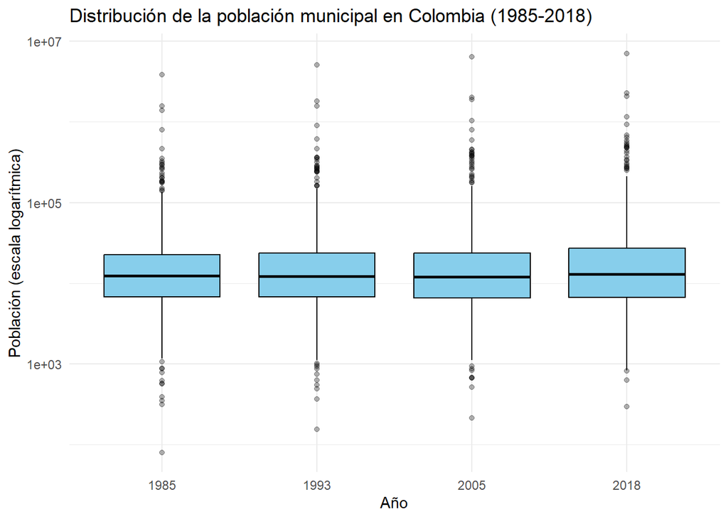

```r
# Ahora un gráfico de boxplot para ver la distribución por año
boxplot_g<- ggplot(pobxarea, aes(x = factor(ano), y = poblacion)) +
          geom_boxplot(fill = "skyblue", color = "black", outlier.alpha = 0.3) +
          scale_y_log10() +  # Log para ver mejor la dispersión
          labs(
          title = "Distribución de la población municipal en Colombia (1985-2018)",
            x = "Año",
            y = "Población (escala logarítmica)"
               ) +
                theme_minimal()
print(boxplot_g)
```

La distribución de la población municipal en Colombia muestra un patrón estable en la mayoría de los municipios a lo largo del tiempo, pero con un aumento progresivo en los valores extremos (outliers).

El rango intercuartílico (IQR) —la “caja” del boxplot— se mantiene relativamente similar entre 1985 y 2018, lo que indica que la mayoría de los municipios han tenido un crecimiento poblacional moderado y relativamente homogéneo.

Sin embargo, se observa un incremento en la dispersión hacia arriba, especialmente a partir de 2005 y 2018: los municipios más poblados (outliers superiores) han crecido mucho más que el resto.

Esto refleja un proceso de concentración urbana: mientras la mayoría de municipios permanecen pequeños o medianos, un grupo reducido de ciudades concentra cada vez una proporción mayor de la población.

El uso de escala logarítmica confirma que existen fuertes desigualdades en el tamaño poblacional municipal, y que estas desigualdades se han intensificado con el tiempo.